# Fitting a simple hierarchical model in R using Template Model Builder

Charles Perretti

2018-08-02

## Introduction

This is an example of how to fit a simple hierarchical model in R using Template Model Builder ([TMB](https://github.com/kaskr/adcomp)). I’ll describe why you might want to use a hierarchical model, then I’ll show how to code it up and fit it in TMB. I won’t go too deep into the mechanics of TMB (full documentation can be found [here](https://kaskr.github.io/adcomp/_book/Introduction.html)), instead I’ll focus on introducing the idea of hierarchical modelling and how to fit one such model in TMB.

Let’s start with why you might want to use a hierarchical model.

Imagine we have a bunch of field sites and we want to estimate the mean of some variable at each of those sites. We take multiple samples from each site, and we’re going to use those samples to calculate our means. Now we could just average the samples from each site to get their mean, but that would ignore the fact that the sites all share some characteristics in common. On the other extreme, we could just pool all of the data together and calculate one mean for all the groups, but that would ignore the fact that each site is somewhat unique. We should be able to get the best estimates by “partially pooling” information across sites. This sharing of information is the central advantage of hierarchical models. The trick is to figure out how much pooling to do. Fortunately the model figures this out for us.

Here is a simple example. Let’s say the observations from each field site are normally distributed about their true site mean, and the sites means themselves are normally distributed about some global mean. In other words, the site means are a random effect. That is, the observations come from the following hierarchical model:

$$Y_{i,a} \sim N(\mu_a, \theta)$$
$$\mu_a \sim N(\mu, \sigma)$$

Where $Y_{i,a}$ is observation $i$ in site $a$, which is normally distributed about the site mean $\mu_a$, and each site mean is itself normally distributed about the global mean $\mu$.

Importantly, the site means all come from the same normal distribution, and this acts to shrink their estimates towards the global mean $\mu$. The value of $\sigma$ determines the amount of pooling, or shrinking of the estimates toward the global mean. If $\sigma$ is large, then the site means are allowed to be very different from each other, and therefore the pooling and shrinkage is weak. On the other hand, if $\sigma$ is small then pooling and shrinkage is strong, and the site means will be quite similar. The model will find the value of $\sigma$ that maximizes the likelihood of the data, so you don’t have to worry about specifying the amount of pooling yourself.

## Simulation

Next let’s simulate some data from this hierarchical model, just to see what it looks like. Then we’ll code it up in TMB and fit it to the simulated data.

```r
# Load required packages
library(ggplot2) # For plots
library(dplyr) # For data manipulation

set.seed(12345) # For reproducibility

# Settings for sites
n_sites <- 10
n_obs_per_site <- 100
sd_site <- 10

# Settings for global distribution
global_mean <- 100
sd_global <- 20

# Expectation for each site is normal around the global mean
site_mean_a <- rnorm(mean = global_mean,
                      sd = sd_global,
                      n = n_sites)

# Expectation for each sample is normal around the site mean
site_obs_ia <- rnorm(mean = rep(site_mean_a, each = n_obs_per_site),
                      sd = sd_site,
                      n = n_sites * n_obs_per_site)
```

We’ve set up the model to have 10 sites with 100 observations per site, and we’ve chosen parameter values for the global mean (global_mean <- 100) the standard deviation of the site means (sd_global <- 20), and the standard deviation of the observations from each site (sd_site <- 10).

Here is a plot of the data:

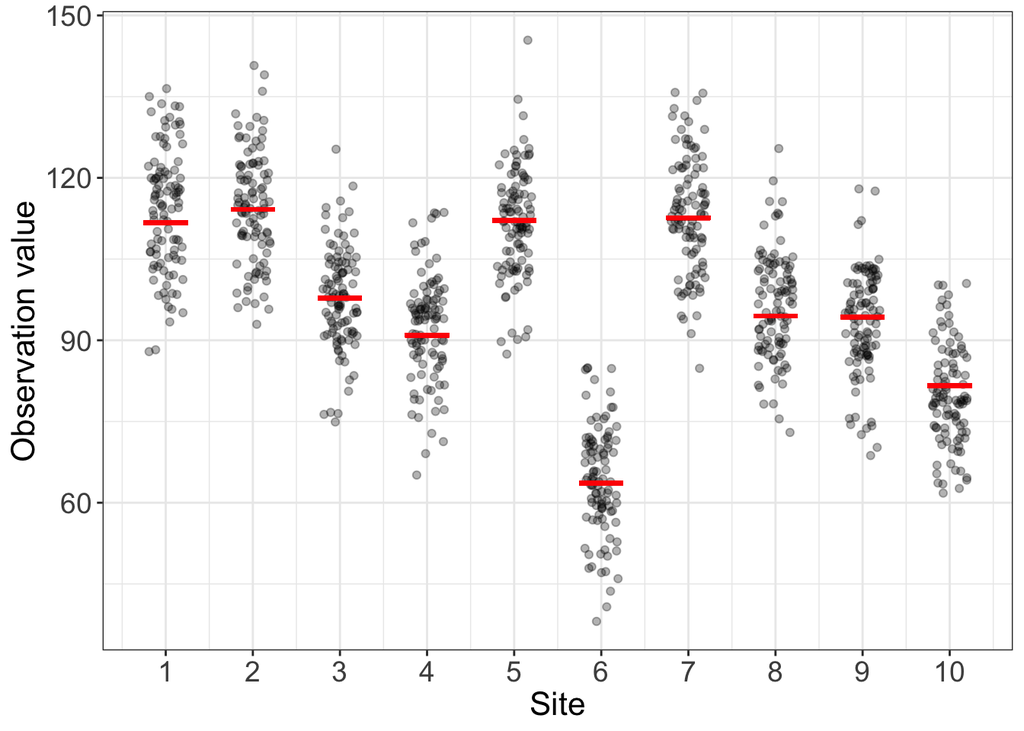

The observations for each site are shown clustered around their site mean in red. The scatter around each mean is normally distributed, and if we simulated many sites and plotted a histogram of the site means we would see that they are normally distributed around the global mean $\mu$.

## Fit the model in TMB

Next let’s code up this model in TMB so we can fit it to the simulated data. The full TMB file can be viewed [here](https://github.com/perretti/posts/tree/master/simple_hierarchical). I’ll break it down into chunks below.

The first part of the TMB file links the TMB libraries and defines the data and parameters.

```r
writeLines(readLines("simple_hierarchical.cpp")[1:16])
```

```
#include <TMB.hpp>
template<class Type>
Type objective_function<Type>::operator() ()
{
  // Data
  DATA_VECTOR(site_obs_ia);
  DATA_IVECTOR(site_index_i);
  DATA_SCALAR(log_sd_site);


  // Parameters
  PARAMETER_VECTOR(site_mean_a);
  PARAMETER(global_mean);
  PARAMETER(log_sd_global);
```

The standard deviation parameters (`sd_global` and `sd_site`) are input as logged values. If we didn’t do this then the optimizer might try negative values for these parameters which would lead to numerical problems. By logging the standard deviations the optimizer is free to try negative values as these will just be converted to small positive values after exponentiating.

Next we initialize the objective function at zero (labeled “jnll” for joint negative log-likelihood), and define the probability of the site means and the observations.

```r
writeLines(readLines("simple_hierarchical.cpp")[17:37])
```

```
  // Objective function
  Type jnll = 0;

  Type sd_global = exp(log_sd_global);

  // Probability of site means
  int n_site = site_mean_a.size();
  for( int s = 0; s < n_site; s++) {
    jnll -= dnorm(site_mean_a(s),
                  global_mean,
                  sd_global, true);
  }

  // Probability of observations
  Type sd_site = exp(log_sd_site);
  int n_site_obs = site_obs_ia.size();
  for(int i = 0; i < n_site_obs; i++) {
    jnll -= dnorm(site_obs_ia(i),
                  site_mean_a(site_index_i(i)),
                  sd_site, true);
  }
```

At the end of the file we ask TMB to report the parameter estimates and uncertainties for the global mean, global standard deviation, and site means. We also report the value of the function we are asking TMB to minimize (the joint negative log-likelihood).

```r
writeLines(readLines("simple_hierarchical.cpp")[38:46])
```

```
  // Reporting
  ADREPORT(global_mean);
  ADREPORT(sd_global);
  ADREPORT(site_mean_a);


  return jnll;
}
```

Now that we have the model in TMB we can go ahead and fit it to the simulated data. We do this in R.

First we compile the model so it’s ready to be used.

```r
# Compile model
library(TMB)
Version <- "simple_hierarchical"
compile( paste0(Version,".cpp") )
```

Then we arrange the data and parameters for input into TMB. When we input the list of parameters we also give their initial values of the optimization routine.

```r
# Setup data
Data <- list("site_obs_ia" = site_obs_ia,
             "site_index_i" = rep((1:n_sites) - 1, each = n_obs_per_site),
             "log_sd_site" = log(sd_site))
# Setup parameters and starting values
Parameters <- list("global_mean" = 0,
                   "log_sd_global" = 0,
                   "site_mean_a" = rep(0, n_sites))
```

Next we build the TMB object, and fit it using a built-in optimizer. The most important thing to notice in this block of code is the setting `random = "site_mean_a"`. This is telling TMB to estimate the distribution of site means as a random effect, which it does using the Laplace approximation. In this simple example you can actually fit the model without that setting, but the Laplace approximation becomes important in more complicated models as it allows you to very quickly fit models with many parameters.

```r
# Build object
dyn.load(dynlib(Version))
Obj <- MakeADFun(data = Data,
                 parameters = Parameters,
                 random = "site_mean_a")

# Optimize
Opt <- TMBhelper::Optimize(obj = Obj, newtonsteps = 1)
```

Next we extract the parameter estimates and standard errors.

```r
# Report out the ADREPORT vars
Report_sd <- TMB::sdreport(Obj)
```

## Results

Now let’s inspect the parameter estimates and compare them to the true values from the simulation. First let’s plot the estimated site means against the true means.

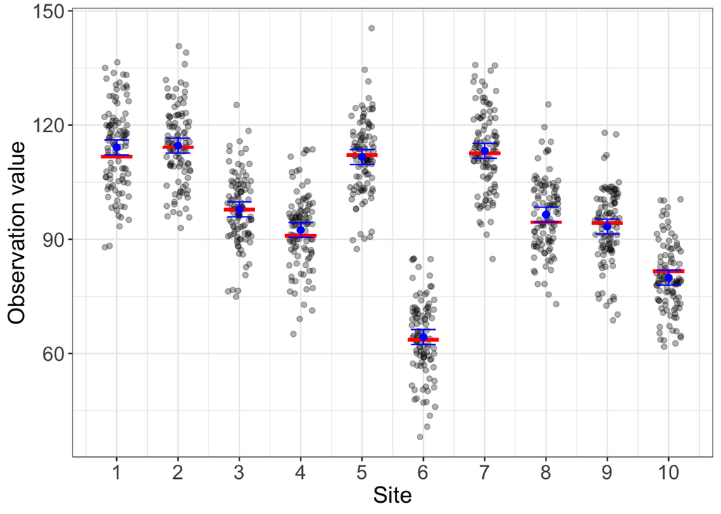

The blue points are the estimated site means and 95% confidence intervals. The true sites means in red are mostly within the 95% interval of the estimated means, a good sign.

Now let’s see how well we estimated the global mean and standard deviation.

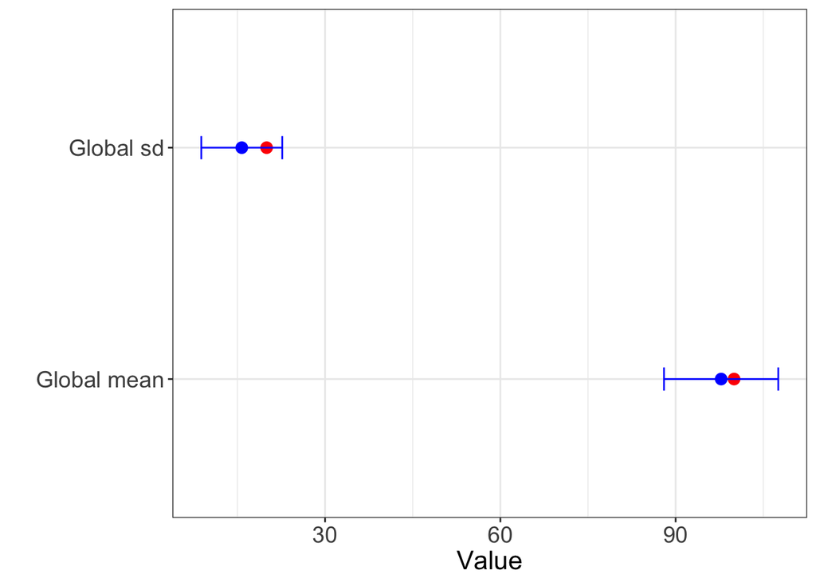

Both the mean and the standard deviation of the global distribution are within the 95% confidence interval of the parameter estimates which is another indication that the model is working as expected.

## Conclusion

Hopefully this was a helpful introduction to hierarchical modelling and TMB. There are a lot of ways to extend this simple model. For example, you could allow each group to have its own observation standard deviation by putting a distribution on $\theta$. Or you could model the mean of each group as a linear model of some covariates (e.g., a GLMM). The flexibility of the hierarchical concept is what makes it so useful.